# Sectorlandia

November 17, 2023

Library $\uparrow$ Nav Hub | Simulation Studies | BI Transmission

The malaria landscape of Sectorlandia is remarkably similar to the northern part of Bioko Island. In sectorlandia, we are interested in spatial targeting and tailoring at a reasonably fine spatial grain.

## Sectors & Areas

We subdivide the landscape into areas and sectors:

- There are 84 areas, each one approximately 1 km $\times$ 1 km
- There are 2502 sectors, each one approximately 100 m $\times$ 100 m

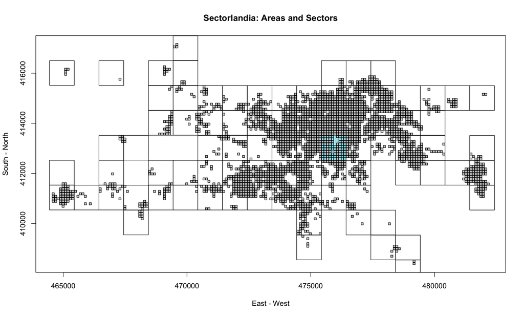

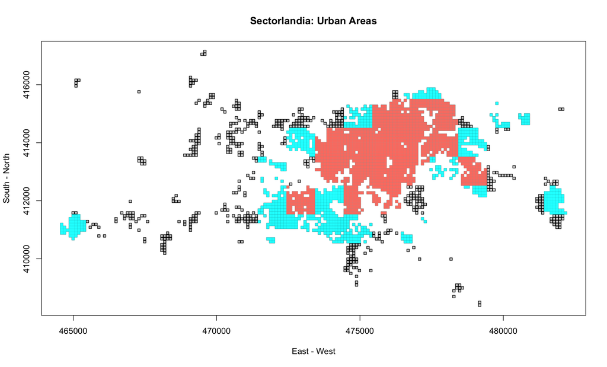

## Humans

### Pop

Some basic information about the human populations:

The population is highly unevenly distributed. These are the histograms of population density and logged population density:

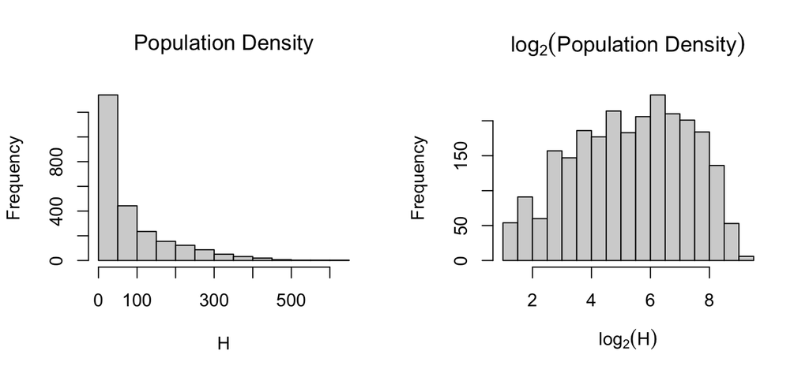

We can show how the population is distributed on the map by coloring the pixels – the lighter in color, the more densely it is populated.

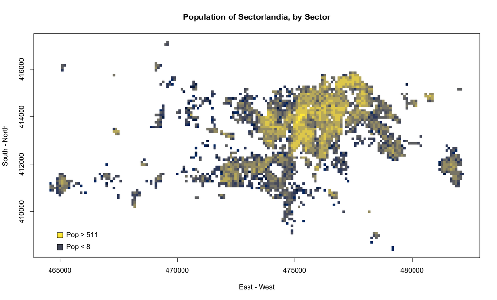

### Travel

We want to simulate regional travel by populations that has a spatial pattern. This is a histogram of the values we’ve generated:

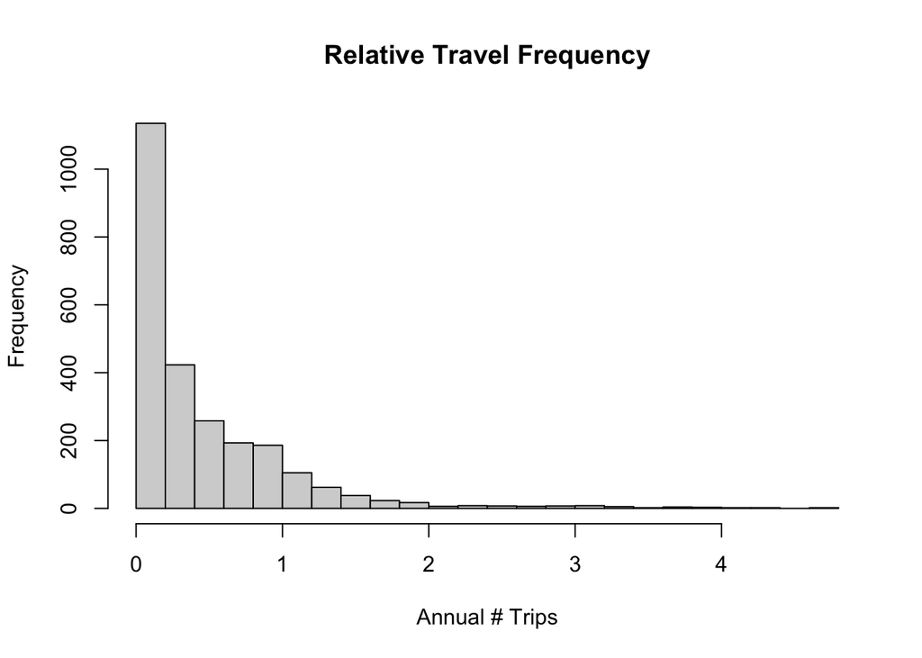

The distribution of propensity to travel can be illustrated by coloring the pixels on a map:

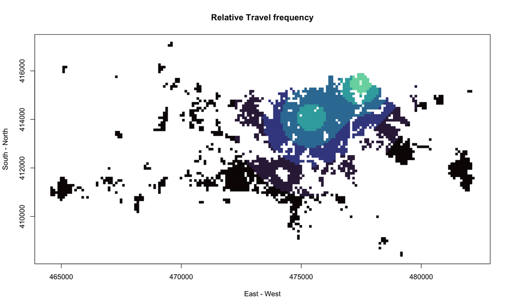

The distribution of propensity to travel can be illustrated by coloring the pixels on a map:

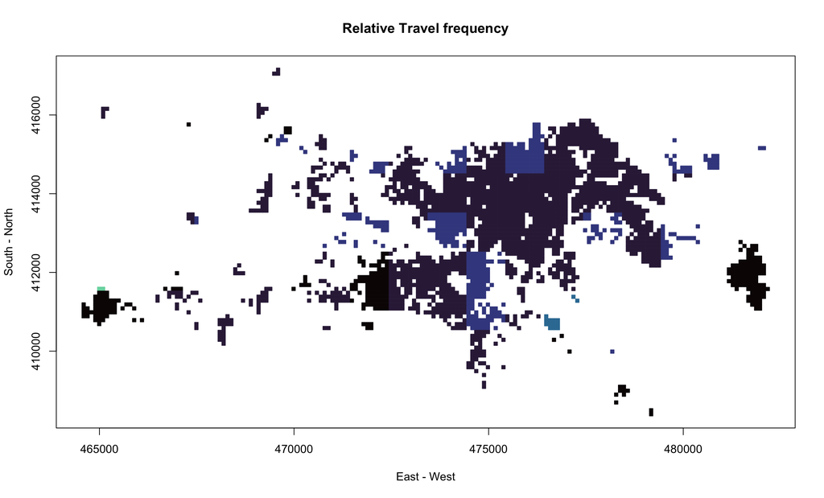

### Habitats

For now, we used a forced emergence model.

## Studies

- The first study we did was A Primary Assessment of Malaria Transmission in Sectorlandia